# Designed Experiment

May 15, 2019

```r
library(car)
library(mosaic)
library(tidyverse)
library(DT)
library(pander)
library(readr)
library(plotly)
library(ggplot2)

#Yes C, Yes O
SELF <- read_csv("../Data/SELF.csv")

#No C, Yes O
SELF2 <- SELF %>%
  filter(BPM > 50)

#No C, No O
SELFO <- SELF2 %>%
  filter(Score.SS != 18)

#Yes C, No O
SELFCo <- SELF %>%
  filter(Score.SS != 18)
```

## My Experiment!

I am testing how music effects my focus. I am running the test using a color pattern game on my phone, called Simon Says. I am terrible at this game and it takes a lot of focus for me to do well. I will be measuring if the beats per minute (BPM) of the songs effect my focus (data collected from an online [website](https://songbpm.com/)). I decided on this study because I like to listen to music while working on my homework, so I wanted to see if different songs gave different results.

Specifically, I am asking whether the BPM of a song has an effect on my focus?

$$H_o: \beta_1 = 0$$
$$H_a: \beta_1 \neq 0$$
$$\alpha = 0.05$$

For this experiment I will use the mathematical model:
$$\underbrace{Y_i}_\text{An individuals Y}=\underbrace{\overbrace{\beta_0}^\text{y-intercept} + \overbrace{\beta_1}^\text{slope} \overbrace{X_i}^\text{An individuals X} \ }_\text{true regression relation}+\overbrace{\epsilon_i}^\text{error term}\quad \text{where}\ \overbrace{\epsilon_i \sim N(0, \sigma^2)}^\text{error term normally distributed}$$

Collecting the data I was very careful to try to randomize the order of BPM so I didn’t get tires and cause a correlation accidentally. I also selected songs with a similar sound, they all have lyrics, and they are all songs I know and like.

## Testing!

The following tabs organize four variations of my linear regression. C stands for control, and O stands for outlier.

### Yes C, Yes O

```r
SELF.lmC <- lm(Score.SS ~ BPM, data = SELF)
pander(summary(SELF.lmC))
```

|  | Estimate | Std. Error | t value | Pr(>\|t\|) |
| --- | --- | --- | --- | --- |
| **(Intercept)** | 9.488 | 0.841 | 11.28 | 3.529e-20 |
| **BPM** | -0.01366 | 0.006853 | -1.993 | 0.04871 |

Fitting linear model: Score.SS ~ BPM

| Observations | Residual Std. Error | $R^2$ | Adjusted $R^2$ |
| --- | --- | --- | --- |
| 114 | 2.784 | 0.03425 | 0.02562 |

**My specific model for this regression is:** $\underbrace{\hat{Y}_i}_\text{Average Y value} = 9.488-0.01366 \underbrace{X_i}_\text{Observed X value}$

Diagnostic Plots

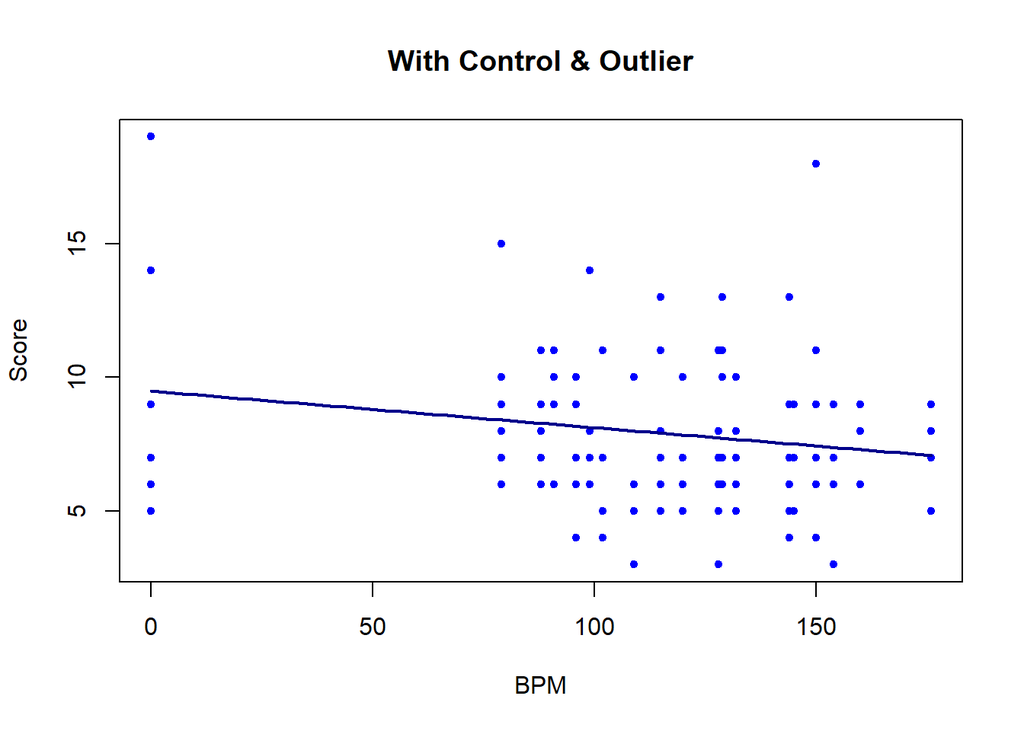

```r
plot(Score.SS ~ BPM, data = SELF, ylab = "Score", main = "With Control & Outlier", col = "blue", pch = 20)
curve(9.488-0.01366*x, add = T, col = "darkblue", lwd = 2)
```

### No C, No O

```r
SELF.lmO <- lm(Score.SS ~ BPM, data = SELFO)
pander(summary(SELF.lmO))
```

|  | Estimate | Std. Error | t value | Pr(>\|t\|) |
| --- | --- | --- | --- | --- |
| **(Intercept)** | 9.217 | 1.081 | 8.525 | 1.216e-13 |
| **BPM** | -0.01249 | 0.008591 | -1.453 | 0.1491 |

Fitting linear model: Score.SS ~ BPM

| Observations | Residual Std. Error | $R^2$ | Adjusted $R^2$ |
| --- | --- | --- | --- |
| 107 | 2.4 | 0.01972 | 0.01038 |

**My specific model for this regression is:** $\underbrace{\hat{Y}_i}_\text{Average Y value} = 9.217-0.01249 \underbrace{X_i}_\text{Observed X value}$

Diagnostic Plots

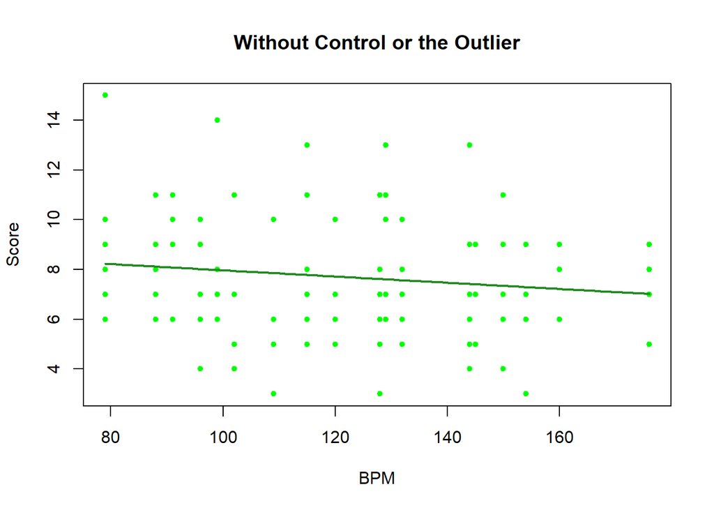

```r
plot(Score.SS ~ BPM, data = SELFO, ylab = "Score", main = "Without Control or the Outlier", col = "green", pch = 20)
curve(9.217-0.01249*x, add = T, col = "forestgreen", lwd = 2)
```

### No C, Yes O

```r
SELF.lm <- lm(Score.SS ~ BPM, data = SELF2)
pander(summary(SELF.lm))
```

|  | Estimate | Std. Error | t value | Pr(>\|t\|) |
| --- | --- | --- | --- | --- |
| **(Intercept)** | 8.869 | 1.168 | 7.594 | 1.282e-11 |
| **BPM** | -0.008857 | 0.009261 | -0.9564 | 0.3411 |

Fitting linear model: Score.SS ~ BPM

| Observations | Residual Std. Error | $R^2$ | Adjusted $R^2$ |
| --- | --- | --- | --- |
| 108 | 2.6 | 0.008555 | -0.0007985 |

**My specific model for this regression is:** $\underbrace{\hat{Y}_i}_\text{Average Y value} = 8.869-0.008857 \underbrace{X_i}_\text{Observed X value}$

Diagnostic Plots

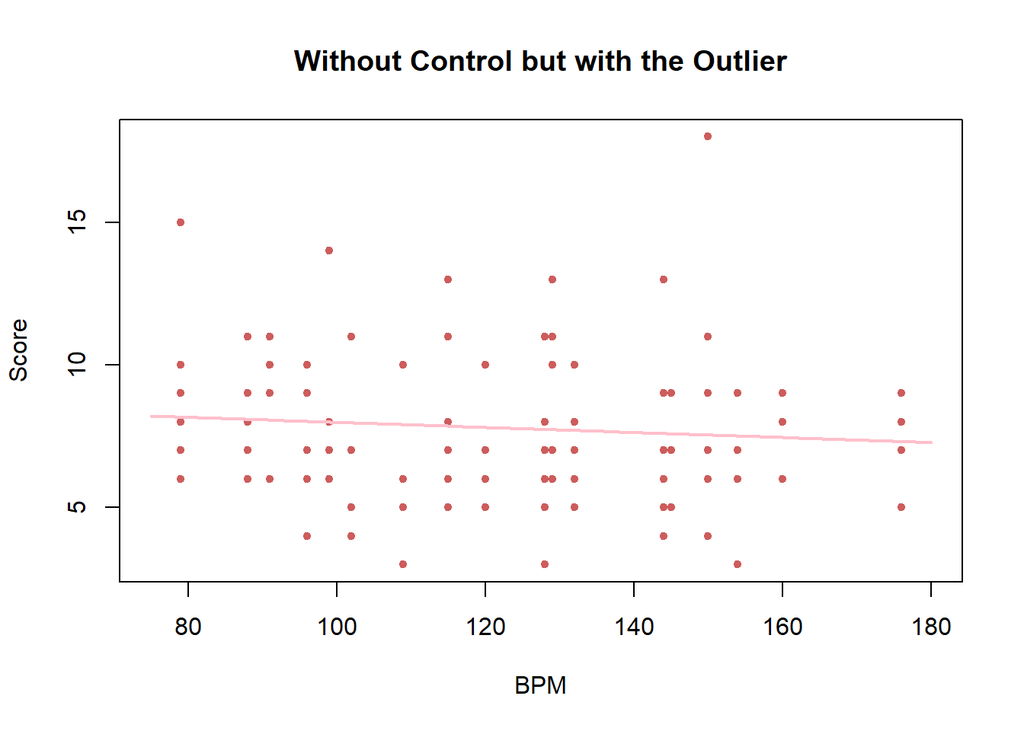

```r
plot(Score.SS ~ BPM, data = SELF2, xlim = c(75, 180), ylab = "Score", main = "Without Control but with the Outlier", col = "indianred", pch = 20)
curve(8.869-0.008857*x, add = T, col = "pink", lwd = 2)
```

### Yes C, No O

```r
SELF.lmCO <- lm(Score.SS ~ BPM, data = SELFCo)
pander(summary(SELF.lmCO))
```

|  | Estimate | Std. Error | t value | Pr(>\|t\|) |
| --- | --- | --- | --- | --- |
| **(Intercept)** | 9.647 | 0.7887 | 12.23 | 2.658e-22 |
| **BPM** | -0.01582 | 0.00644 | -2.457 | 0.01557 |

Fitting linear model: Score.SS ~ BPM

| Observations | Residual Std. Error | $R^2$ | Adjusted $R^2$ |
| --- | --- | --- | --- |
| 113 | 2.607 | 0.05157 | 0.04302 |

**My specific model for this regression is:** $\underbrace{\hat{Y}_i}_\text{Average Y value} = 9.647-0.01582 \underbrace{X_i}_\text{Observed X value}$

Diagnostic Plots

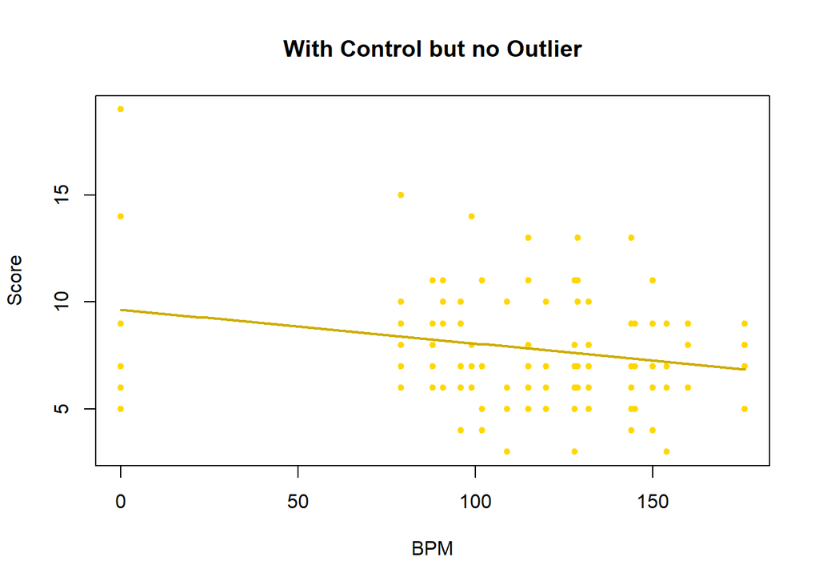

```r
plot(Score.SS ~ BPM, data = SELFCo, ylab = "Score", main = "With Control but no Outlier", col = "gold1", pch = 20)
curve(9.647-0.01582*x, add = T, col = "gold3", lwd = 2)
```

## Results!

Well, as we can see, the correlation is really weak at best. Two of the four tests (yes-yes, and yes-no) had significant p-values for the slop and the other two did not. Honestly, I don’t know if it was legal to play with my data the way I did but it provided some interesting insight.

It looks like there is no significance to the BPM of music I listen to but there is a significance to the difference between listening to any music and not listening to music. But maybe the high average in my control testing was a fluke. I can’t really tell om this one test with so many uncontrollable variables and such.

Overall, I’d say either I ran a terrible experiment, that the BPM of the songs I listen to doesn’t have an effect on my focus, or the game I was playing didn’t accurately measure focus.